# Exam 3

McKay Jones

## Part 1: Load and Clean Data

In part 1, I’m going to load and clean the FacultySalaries_1995.csv file and re-create a graph.

First, let’s load some required projects.

I will load the data using the read.csv command, and save it to a ‘dat’ object.

```r
dat <- read.csv('FacultySalaries_1995.csv')
```

Let’s take a look at this data so we know what to clean.

```r
glimpse(dat)
```

```
## Rows: 1,161
## Columns: 17
## $ FedID               <int> 1061, 1063, 1065, 11462, 1002, 1004, 1008, 1009, 1…
## $ UnivName            <chr> "Alaska Pacific University", "Univ.Alaska-Fairbank…
## $ State               <chr> "AK", "AK", "AK", "AK", "AL", "AL", "AL", "AL", "A…
## $ Tier                <chr> "IIB", "I", "IIA", "IIA", "IIA", "IIA", "IIB", "I"…
## $ AvgFullProfSalary   <int> 454, 686, 533, 612, 442, 441, 466, 580, 498, 506, …
## $ AvgAssocProfSalary  <int> 382, 560, 494, 507, 369, 385, 394, 437, 379, 412, …
## $ AvgAssistProfSalary <int> 362, 432, 329, 414, 310, 310, 351, 374, 322, 359, …
## $ AvgProfSalaryAll    <int> 382, 508, 415, 498, 350, 388, 396, 455, 401, 411, …
## $ AvgFullProfComp     <int> 567, 914, 716, 825, 530, 542, 558, 692, 655, 607, …
## $ AvgAssocProfComp    <int> 485, 753, 663, 681, 444, 473, 476, 527, 501, 508, …
## $ AvgAssistProfComp   <int> 471, 572, 442, 557, 376, 383, 427, 451, 404, 445, …
## $ AvgProfCompAll      <int> 487, 677, 559, 670, 423, 477, 478, 546, 523, 503, …
## $ NumFullProfs        <int> 6, 74, 9, 115, 59, 57, 20, 366, 34, 67, 8, 106, 27…
## $ NumAssocProfs       <int> 11, 125, 26, 124, 77, 33, 18, 354, 25, 40, 15, 42,…
## $ NumAssistProfs      <int> 9, 118, 20, 101, 102, 35, 30, 301, 27, 66, 19, 66,…
## $ NumInstructors      <int> 4, 40, 9, 21, 24, 2, 0, 66, 3, 27, 2, 58, 4, 19, 3…
## $ NumFacultyAll       <int> 32, 404, 70, 392, 262, 127, 68, 1109, 89, 200, 44,…
```

I’m cleaning the data by removing any ‘VIIB’ schools, and using the pivot_longer command to combine all of the professors’ positions and salaries into two rows. This will make it easier to construct Fig1.

In the newly constructed professor_type column, I made sure to remove redundant information (‘Avg’ in the beginning of the string and ‘ProfSalary’ at the end of the string). Now, all of the values in the professor_type column are ‘Assist’, “Assoc’, and ‘Full’ (instead of ‘AvgAssistProfSalary’, for example).

This ‘tidied’ data was saved to a dat_clean object for dowmstream analyses.

```r
dat_clean <- dat %>%
  filter(Tier != 'VIIB') %>%
  pivot_longer(ends_with('Salary'), names_to = 'professor_type',
               names_prefix = "Avg",
               values_to = 'avg_salary') %>%
  mutate(professor_type = sub("ProfSalary", "", professor_type))
```

I then constructed the desired boxplot image, using facet_wrap() to group all the salaries by school rank. It looks like professors at Rank I schools tend to have higher salaries.

```r
img_1 <- dat_clean %>%
  ggplot(aes(x = professor_type,
             y = avg_salary,
             fill = professor_type)) +
  geom_boxplot() +
  facet_wrap(~Tier) +
  theme_minimal() +
  labs(x = 'Rank', y = "Salary") +
  guides(fill = guide_legend(title = "Rank")) +
  theme(axis.text.x = element_text(angle = 45))
```

Let’s view the image and save it.

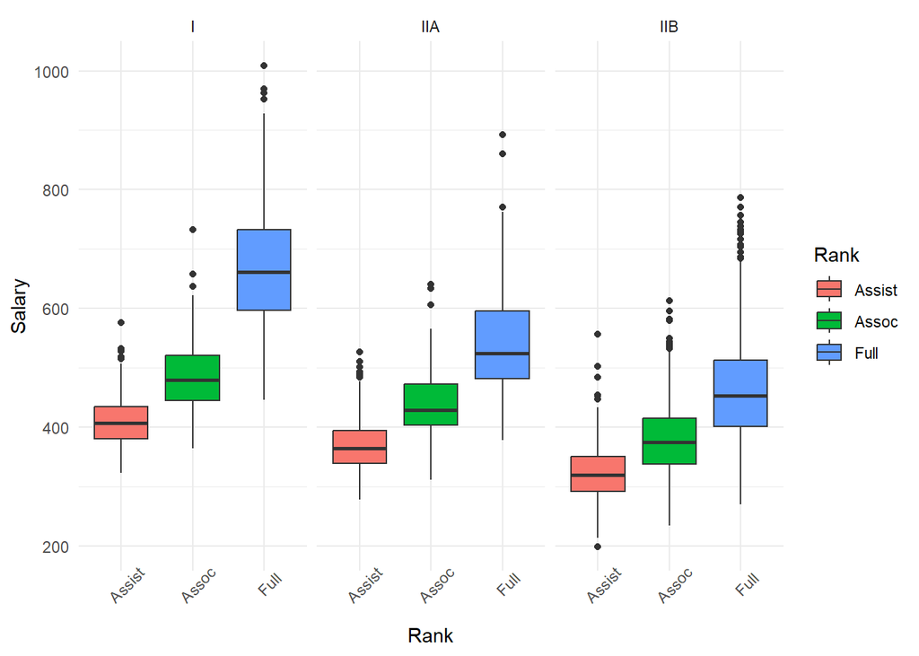

```r
img_1
```

```r
ggsave('Fig1.png', plot = img_1, width = 3, height = 5)
```

## Part 2: ANOVA Model

I am building an ANOVA model that tests the influence of State, School Tier, and Professor Rank/Type on “Salary” with NO interactions between the predictors.

```r
mod_anova <- aov(data = dat_clean, avg_salary~State+Tier+professor_type)

summary(mod_anova)
```

```
##                  Df   Sum Sq Mean Sq F value Pr(>F)
## State            50  5667124  113342   31.17 <2e-16 ***
## Tier              2  7072361 3536180  972.56 <2e-16 ***
## professor_type    2 16526626 8263313 2272.66 <2e-16 ***
## Residuals      3297 11987752    3636
## ---
## Signif. codes:  0 '***' 0.001 '**' 0.01 '*' 0.05 '.' 0.1 ' ' 1
## 128 observations deleted due to missingness
```

## Part 3: Tidy Juniper Dataset

This data set originated from a collaboration between Young Living Inc. and UVU Microbiology.

First, I will load this data into a jun_dat object and take a look.

```r
jun_dat <- read.csv("Juniper_Oils.csv")

glimpse(jun_dat)
```

```
## Rows: 34
## Columns: 41
## $ SampleID               <chr> "LOG-16S-SL12", "LOG-16S-SL11", "LOG-16S-CC5", …
## $ Project                <chr> "JuniperLogs", "JuniperLogs", "JuniperLogs", "J…
## $ Amplicon               <chr> "16S", "16S", "16S", "16S", "16S", "16S", "16S"…
## $ Tree_Species           <chr> "Juniperus osteosperma", "Juniperus osteosperma…
## $ BurnYear               <int> 2018, 2017, 2016, 2014, 2013, 2012, 2011, 2009,…
## $ Latitude               <dbl> 41.5719, 40.9202, 37.5799, 39.9422, 41.5335, 40…
## $ Longitude              <dbl> -113.7488, -113.0017, -113.0851, -112.7181, -11…
## $ Field_Office           <chr> "Salt_Lake_3", "Salt_Lake_2", "Cedar_City", "Sa…
## $ BLM_Fire_Name          <chr> "Ridge", "Knob", "Hicks Creek", "Lion Peak", "P…
## $ Tracking_Number        <chr> "#5276 (2018)", "#5275 (2017)", "#5274 (2016)",…
## $ alpha.pinene           <dbl> 0.6, 1.4, 0.2, 0.3, 0.1, 0.0, 0.1, 0.2, 0.1, 0.…
## $ para.cymene            <dbl> 0.4, 0.3, 1.1, 0.1, 0.1, 0.1, 0.5, 0.6, 0.2, 0.…
## $ alpha.terpineol        <dbl> 2.3, 0.5, 0.8, 0.7, 0.2, 0.1, 2.8, 1.1, 0.1, 0.…
```

[output cut: 28 more lines]

Let’s tidy this dataset. First, I saved the compounds I want to analyze into a ‘chems’ vector. To match the names in this vector, I replaced all of the periods in the original column names with ‘-’.

For ‘compound 1’ and ‘compound 2’, which are separated by a space, I saved these two rows into another object with their ‘-’ replaced with spaces. Then, I used bind_cols to add them back to the original data frame.

```r
chems <- c("alpha-pinene","para-cymene","alpha-terpineol","cedr-9-ene","alpha-cedrene","beta-cedrene","cis-thujopsene","alpha-himachalene","beta-chamigrene","cuparene","compound 1","alpha-chamigrene","widdrol","cedrol","beta-acorenol","alpha-acorenol","gamma-eudesmol","beta-eudesmol","alpha-eudesmol","cedr-8-en-13-ol","cedr-8-en-15-ol","compound 2","thujopsenal")


jun_dat2 <- jun_dat %>%
  rename_with(~ gsub("\\.", "-", .x))

compounds <- jun_dat2 %>%
  select(starts_with('compound')) %>%
  rename_with(~ gsub("\\-", " ", .x))

jun_dat3 <- jun_dat2 %>%
  select(-starts_with('compound')) %>%
  bind_cols(compounds)
```

Now, I will use the pivot_longer command on the chemicals and Mass-Spec concentrations of each one. This will be helpful for the figure we want to make.

```r
jun_dat4 <- jun_dat3 %>%
  pivot_longer(chems, names_to = 'chemical',
               values_to = 'concentration')
```

## Part 4: Make a Graph

I will make a graph, with x = YearSinceBurn, y = Concentration, and facet = ChemicalID

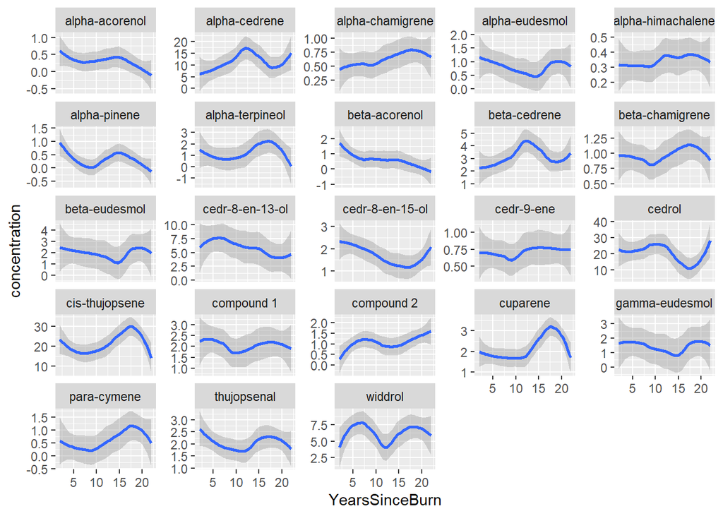

```r
img_2 <- jun_dat4 %>%
  ggplot(aes(x = YearsSinceBurn,
             y = concentration)) +
  geom_smooth() +
  facet_wrap(~chemical, scales = 'free_y')

img_2
```

## Part 5: Find chemicals that are significantly affected

Now, I am going to use a generalized linear model to find which chemicals show concentrations that are significantly affected by “Years Since Burn”.

```r
models <- jun_dat4 %>%
  group_by(chemical) %>%
  do(tidy(glm(concentration ~ YearsSinceBurn, data = .)))

sig_chems <- models %>%
  filter(term == "YearsSinceBurn",
         p.value < 0.05) %>%
  arrange(p.value)

sig_chems
```

```
## # A tibble: 3 × 6
## # Groups:   chemical [3]
##   chemical      term           estimate std.error statistic p.value
##   <chr>         <chr>             <dbl>     <dbl>     <dbl>   <dbl>
## 1 beta-acorenol YearsSinceBurn  -0.0655    0.0226     -2.90 0.00664
## 2 cuparene      YearsSinceBurn   0.0550    0.0244      2.26 0.0310
## 3 compound 2    YearsSinceBurn   0.0356    0.0173      2.06 0.0471
```